# Education Around the World

Author: Kristina Krasteva

## 1. Introduction

During the last month since we have been studying online, I started to think about the great importance of education. When we think about it, education is one of the things that we refuse to give up even during the virus. As if in the last decades constantly receiving knowledge and applying it has turned into something we cannot live without just like eating, drinking water and sleeping.

Education is not only key to us as individuals but also to all of the 17 SDGs. Thanks to it, people have the power to make good, informed decisions in different areas of their lives. Education breaks the cycle of poverty because it means better jobs and higher incomes for individuals and families, and it increases national productivity and economic growth. For example, a child born to a literate mother is 50% more likely to survive past the age of five than a child born to an illiterate mother - because the mother is more able to get and understand information about health care.

The purpose of these visualizations are show where access to education is most needed, where inequality to education is most prevalent, and potential solutions to address these issues in relation to goal 4 of the SDGs.

## 2. Heatmap

### 2.1. SetUp

```python
import pandas as pd
import seaborn as sns
import matplotlib.pyplot as plt
```

```python
# helper function
def assign_continent(country_code):
    """given a 3 letter country code,
    return the continent the country belongs to"""
    try:
        row = country_to_continent[country_to_continent.Three_Letter_Country_Code == country_code]
        continent = row.Continent_Name.values[0]
        return continent
    except:
        return None
```

### 2.2. Pre-Processing

1. Filter Columns
2. Rename Columns
3. Assign each continennt to each country
4. Filter out the non-country level rows
5. Pivot

```python
# read in data
entry = pd.read_csv('../data/entry_to_primary_edu.csv')
country_to_continent = pd.read_csv('../data/country_continent.csv')

# 1. filter
country_to_continent = country_to_continent[['Three_Letter_Country_Code', 'Continent_Name', 'Country_Name']]
entry = entry[['Indicator', 'LOCATION', 'Country', 'Time', 'Value']]
entry = entry[entry.Time != 2018]  # 2018 missing data

# 2. rename column
entry = entry.replace('New entrants to Grade 1 of primary education, female (number)', 'Girls')
entry = entry.replace('New entrants to Grade 1 of primary education, male (number)', 'Boys')

# 3. Assign each country their continent
entry['Continent'] = entry.LOCATION.apply(lambda x: assign_continent(x))

# 4. keep only country level rows
countries = country_to_continent.Three_Letter_Country_Code.unique()
entry_by_country = entry[entry.LOCATION.isin(countries)]

# 5. pivot
entry_pivot = pd.pivot_table(entry_by_country, values='Value',
                             index=['Continent', 'LOCATION', 'Country', 'Time'],
                             columns='Indicator')
```

### 2.3. Calculations

```python
# total enrollment by continent
entry_by_continent = entry_pivot.groupby(['Continent', 'Time']).sum()

# % of difference in enrollment rate boy vs girls
entry_by_continent['Dif%'] = entry_by_continent.apply(lambda x: ((x[0]/(x[0] + x[1])) - (x[1]/(x[0] + x[1])))*100,
                                                      axis=1)

entry_by_continent.head()
```

| Continent | Indicator Time | Boys | Girls | Dif% |
| --- | --- | --- | --- | --- |
| Africa | 2014 | 14242943.00 | 13325643.00 | 3.327338 |
|  | 2015 | 13078330.00 | 11588142.00 | 6.041350 |
|  | 2016 | 11213580.04 | 10211340.81 | 4.677913 |
|  | 2017 | 9219238.00 | 8763717.00 | 2.533071 |
| Asia | 2014 | 34920277.00 | 31515025.00 | 5.125666 |

### 2.4. Plot

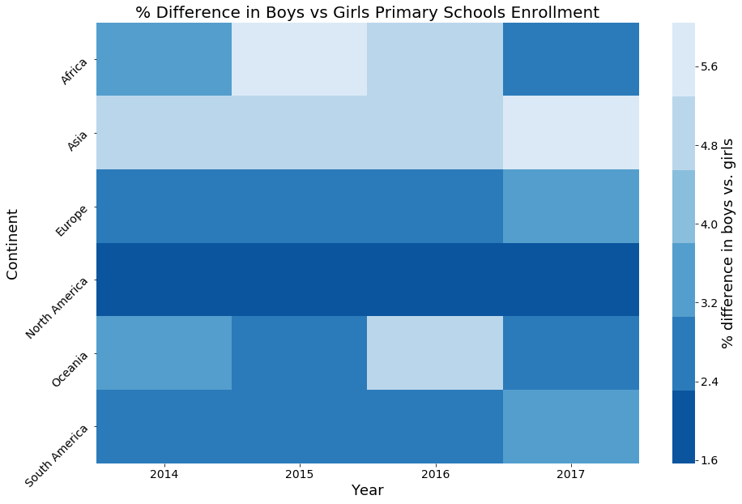

```python
# data to plot
matrix = entry_by_continent.reset_index().pivot(index='Continent', columns= 'Time', values='Dif%')

# plot size
plt.figure(figsize=(15,10))

# title
plt.title('% Difference in Boys vs Girls Primary Schools Enrollment',
         fontsize=20)

# data
sns.heatmap(matrix, cmap=sns.color_palette("Blues_r"),
           cbar_kws=dict(use_gridspec=False,location="right", label='% difference in boys vs. girls'))

# color bar
cax = plt.gcf().axes[-1]
cax.tick_params(labelsize=14)
cax.yaxis.label.set_size(18)

# axis
plt.xlabel('Year', fontsize=18)
plt.ylabel('Continent', fontsize=18)
plt.tick_params(axis='y', labelrotation=45)
plt.tick_params(labelsize=14)

# plt.show()
plt.savefig('HeatMap')
```